# Lab Notes - Scipy Optimization

**Kannan Singaravelu**

kannan.singaravelu@fitchlearning.com

## Overview of Optimization

Optimization is the selection of a best element or solution from some set of available alternatives. Whether it is a portfolio construction or reducing the error of linear regression or some algorithm, optimization plays a critical role in quantitative finance. Optimization in Python is proved to be effective with libraries like Scipy.

The *scipy.optimize* submodule is analogous to MATLAB's optimization toolbox and has the following capabilities:

- Optimization: local, global and minimizers
  - *`minimize_scalar()`* and *`minimize()`*
- Fitting
  - *`curve_fit()`*
- Root Finding
  - *`root_scalar()`* and *`root()`*
- Linear Programming and other utilities
  - *`linprog()`*

## Optimization Algorithms

The optimization algorithms can be broadly categorized as follows based on the type of constraints.

- Unconstrained minimization
  - Derivative-free: `Nelder-Mead`, `Powell`
  - Gradient-based (no Hessian): `CG`, `BFGS`
  - Gradient-based: `Newton-CG`, `dogleg`, `trust-ncg`
- Constrained minimization
  - Only bound constraints: `L-BFGS-B`, `TNC`
  - General constraints: `COBYLA`, `SLSQP`
- Global optimization (derivatives free)
  - `basinhopping`, `brute`, `differential_evolution`

## Minimization Examples

```python
# Import required libraries
import numpy as np
import matplotlib.pylab as plt
from scipy.optimize import minimize_scalar, minimize
```

### Unconstrained Optimization

Let's find the minimum of an objective Function

$$f(x)=x^2-2x$$

which is, $$\underset{x}{minimize} \space\space x^2 -2x$$

#### *`minimize_scalar`*

Function for minimizing one variable

```python
# Define objective function
def objective_function(x):
    return x**2 -2*x
```

```python
results1 = minimize_scalar(objective_function)
```

```python
results1
```

```
     fun: -1.0
    nfev: 8
     nit: 4
 success: True
       x: 1.0
```

#### *`minimize`*

Function for minimizing many variables and can handle

- Multivariate inputs and outputs
- More complicated optimization algorithms
- Constraints

Broadly, we can specify three types of constraints: *`linear`*, *`non-linear`* and *`bounds`*

```python
# Initial Guess
X0 = 3.0
```

```python
# Optimize the function
results2 = minimize(fun=objective_function, x0=X0)
```

```python
# Ouput the result
results2
```

```
      fun: -0.9999999999999998
 hess_inv: array([[0.5]])
      jac: array([2.98023224e-08])
  message: 'Optimization terminated successfully.'
     nfev: 9
      nit: 2
     njev: 3
   status: 0
  success: True
        x: array([1.00000001])
```

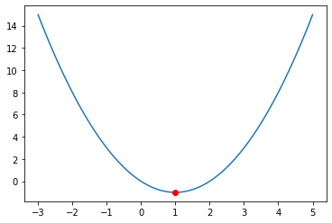

```python
# Plot the function
x = np.linspace(-3,5,100)
plt.plot(x,objective_function(x))
plt.plot(results2.x,objective_function(results2.x),'ro')
```

```python
# Define objective function
def objective_function_with_coeff(x, coeffs):
    return coeffs[0]*x**2 + coeffs[1]*x
```

Now that we have objective function with coefficients, we need to pass it in our minimization function

```python
# Specify Co-efficients (optional for this example)
coeff = [1., -2., 0.]
```

```python
# Optimize the function with coeff
results3 = minimize(fun=objective_function_with_coeff, x0=X0, args=coeff)
```

```python
results3
```

```
      fun: -0.9999999999999998
 hess_inv: array([[0.5]])
      jac: array([2.98023224e-08])
  message: 'Optimization terminated successfully.'
     nfev: 9
      nit: 2
     njev: 3
   status: 0
  success: True
        x: array([1.00000001])
```

### Constrained Optimization

Let's find the minimum of an objective Function $f(x)=x^2-2x$, subject to $x-2 \geq$ 0.

which is, $$\underset{x}{minimize} \space\space x^2 -2x$$

s.t. $$x-2 \geq 0$$

```python
# Specify constraints
cons = ({'type': 'ineq', 'fun' : lambda x: np.array([x[0] - 2])})
```

```python
results4 = minimize(objective_function, x0=X0, constraints = cons)
```

```python
results4
```

```
     fun: -1.3322676295501878e-14
     jac: array([2.])
 message: 'Optimization terminated successfully.'
    nfev: 6
     nit: 2
    njev: 2
  status: 0
 success: True
       x: array([2.])
```

Now, let’s consider the separate inequality constraints on individual decision variables, which are known as “box constraints” or “simple bounds”.

```python
# Specify boundary condition
bnds = ((2, None),) # x less than 2 will have a negative values
```

```python
X0, len(bnds)
```

```
(3.0, 1)
```

```python
results5 = minimize(objective_function, x0=X0, method='SLSQP', bounds=bnds)
```

```python
results5
```

```
     fun: 0.0
     jac: array([2.])
 message: 'Optimization terminated successfully.'
    nfev: 6
     nit: 2
    njev: 2
  status: 0
 success: True
       x: array([2.])
```

#### Multiple Constraints

Let's define one more objective function where we minimize more than one varible given inequality, equality and boundary conditions.

$$\underset{x_1, x_2}{minimize} \space\space x_1^2 + x_1 * x_2$$

s.t. $$x_1^3 + x_1* x_2 = 100$$

$$x_1^2 + x_2 \geq 50$$$$-100 \leq x_1, x_2 \leq 100$$

```python
new_objective_function = lambda x: x[0]**2 + x[0]*x[1]

cons = ({'type': 'eq', 'fun' : lambda x: x[0]**3 + x[0]*x[1] - 100},
        {'type': 'ineq', 'fun' : lambda x: x[0]**2 + x[1] - 50})

intial_xs = [1,1]
boundary = ((-100,100), (-100,100))
```

```python
results6 = minimize(new_objective_function, intial_xs, method='SLSQP', bounds=boundary, constraints=cons)
```

```python
results6
```

```
     fun: 96.00000027660178
     jac: array([50.00000095,  2.        ])
 message: 'Optimization terminated successfully.'
    nfev: 42
     nit: 10
    njev: 10
  status: 0
 success: True
       x: array([ 1.99999997, 46.00000084])
```